# Assignment 3

2020-05-21

```r
library(NLRoot)
library(ggplot2)
library(directlabels)
library(ggplot2)
library(grid)
library(ggrepel)
library(GenSA)
library(numDeriv)
```

## **Problema 1**

Per rispondere inizio a studiare la funzione
$$\mathbf{{f(x) = -x^3 + 4x^2 -2}}$$
vedendo che il dominio che essendo un polinomio è continuo su tutto $\mathbb{R}$. Successivamente controllo i limiti per la funzione che tende a $+\infty$ e $-\infty$ ed ottengo
$$\mathbf{
\begin{equation}
\lim_{x\to-\infty}f(x) = +\infty
\end{equation}}$$

$$\mathbf{
\begin{equation}
\lim_{x\to+\infty}f(x) = -\infty
\end{equation}}$$
Successivamente calcolo la derivata prima e la derivata seconda della funzione ed ottengo rispettivamente, per la derivata prima: $\,f'(x) = -3x^2 + 8x\,$ che mi darà due punti di massimo e di minimo per $f'(x) = 0$. Infatti raccogliendo $x$ ottengo $\,x(-3x+8) = 0\,$ per cui ho $\,x = 0; y=-2\,$ e $\,x = \frac83; y=\frac{202}{27}\,$. Per la derivata seconda invece ottengo: $\,f''(x) = -6x + 8\,$ che mi porta a dire che il punto di flesso ascendente sarà per $x=\frac43, y=\frac{74}{27}$. La curva sarà prima convessa e poi concava. Tutte queste analisi rendono più chiaro che avremo sicuramente più di una intersezione per $y=0$. Infatti disegnando otteniamo:

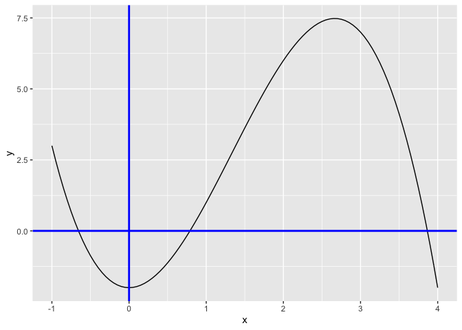

Uso adesso il metodo della **Bisezione** per trovare le intersezioni per $\mathbf{y = 0}$. Decido per comodità di concentrarmi sul trovare un punto analiticamente ma il processo poteva essere fatto per trovare tutti e tre i punti di intersezione e farò solo una iterazione però spiegando come si doveva continuare. Prendo l’intervallo $\mathbf{(3,5)}$ della funzione. Ottenendo:

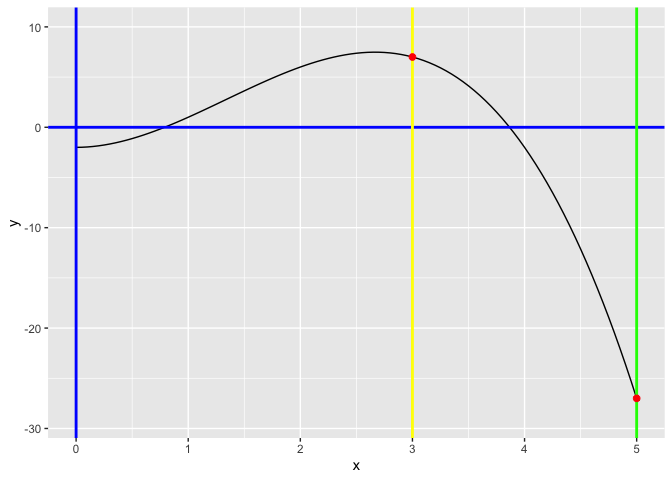

Decido quindi di trovare il punto medio sostituendo alla formula $x_{m} = \frac{a+b}{2}$ rispettivamente 5 e 3, ottenendo che $\mathbf{x_{m} = 4}$ sostituisco poi nella $f(x)$ ed ottengo $f(m) = -2$ mentre ottengo per $\mathbf{f(3) = +7}$ e $\mathbf{f(5) = -27}$.

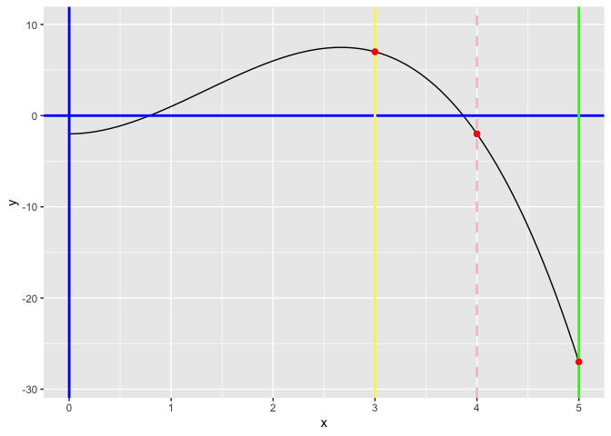

A questo punto secondo il teorema di **Bolzano** sappiamo che se $\mathbf{f(a)\space o\space f(b)}$ hanno segno uguale devo re-iterare l’operazione appena fatta sostituendo l’estremo con il punto medio. Adesso infatti avendo che $\mathbf{f(b)\space e\space f(m)}$ hanno identico segno andrò a trovare il nuovo punto medio con questi valori $\mathbf{x=(3,4)}$. Questo procedimento va avanti finchè arrivo ad una convergenza con $\mathbf{f(x) = 0}$. Utilizzo la libreria **NLRoot** per calcolare le soluzioni per cui $\mathbf{y = 0}$.

```r
BFfzero(func, -2, 10)
```

```
## [1] 1
## [1] -0.6554428
## [1] 2.799172e-06
## [1] 2
## [1] 0.789241
## [1] -1.374113e-05
## [1] 3
## [1] 3.8662
## [1] -2.774007e-05
## [1] "finding root is successful"
```

Ed ottengo perciò 3 soluzioni trovando inoltre anche la nostra abbozzata per cui iterando diverse volte avremmo trovato $\mathbf{x=3.8662\space e\space y=0}$

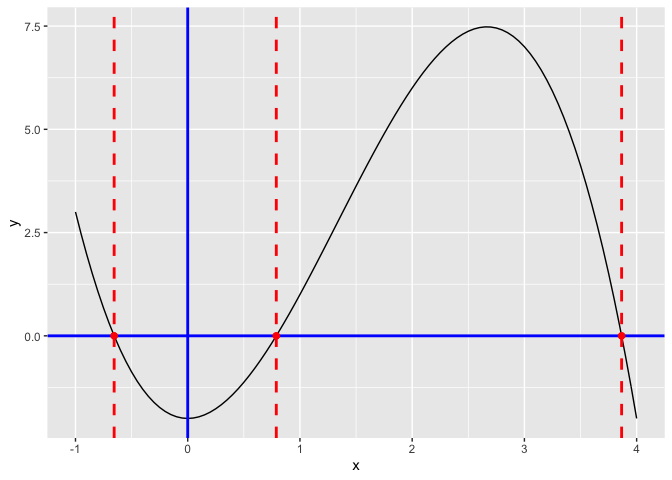

## **Problema 2**

#### **1) Compito (a)**

Presa la funzione
$$\mathbf{2x_1^2 + x_1 x_2\space+ 2(x_2 - 3)^2}$$
dobbiamo utilizzare la discesa del Gradiente per minimizzare la funzione. Per farlo abbiamo bisogno di ricavarci le derivare parziali di $x_1$ e $x_2$ e creare perciò il gradiente così:
$$\nabla f(x_1, x_2) = [4x_1 + x_2,\space x_1+4x_2 -12]$$
.
Ci viene dato il punto $A=(-1,4)^T$ che andando a sostituire nel **gradiente** otteniamo il vettore:
$$\nabla f(A) = [0,\space 3]$$
. A questo punto dobbiamo scegliere un errore $\epsilon$ per cui se la norma del gradiente nel punto é minore di questo $\epsilon$ allora abbiamo raggiunto il minimo.
$$||\nabla f(A)||= \sqrt{0 + (3)^2} < \epsilon$$
L’errore $\epsilon$ è arbitrario e quindi non accettando la ipotesi di soddisfazione del criterio proviamo fare una iterazione, pertanto poichè stiamo cercando il minimo inserisco
$$d_0 = -\nabla f(A) = [0,-3]$$
nella formula
$$x_{k+1} = x_k + a_kd_k$$
ottenendo pertanto
$$B = [-1,4] + a_0[0,-3]$$
cioè
$$B = [-1,4-3a_0]$$
Sostituisco nella equazione di partenza esi ha
$$\nabla f(B) = 18a_{0}^2 -9a_0$$
per cui facendo la derivata prima ottengo
$$\nabla f'(B) = 36a_{0} -9$$
cioè $a_0 = \frac14$. Sostituendo $ a_0$ ho
$$B = [-1,\space\frac{13}{4}]$$
che se uso per calcolare il gradiente ottenendo così
$$\nabla f(B) = [4(-1) + (\frac{13}{4}),\space (-1)+4(\frac{13}{4}) -12] = [-\frac{3}{4}, 0]$$
A questo punto ci serve ricalcolare la norma così da vedere se abbiamo raggiunto il valore ottimale di $ $ per cui
$$||\nabla f(x_k)|| < \epsilon$$
$$||\nabla f(B)||= \sqrt{(-\frac{3}{4})^2 + 0} < \epsilon$$
. Notiamo come dal calcolo precedente per cui $sqrt{0 + (3)^2} =3$ siamo arrivati ad un $\sqrt{(-\frac{3}{4})^2 + 0} \approx 0.75$ che ancora non ci soddisfa. Iterando potremmo sempre di più avvicinarci a $\epsilon \approx 0$.

#### **2) Compito (b)**

Nel compito B si chiede di minimizzare ancora una volta la funzione
$$\mathbf{2x_1^2 + x_1 x_2\space+ 2(x_2 - 3)^2}$$
ma questa volta utilizzando il metodo di Newton. Pertanto una volta calcolate le derivate parziali come nel punto precedente ottenendo perciò il gradiente
$$\nabla f(x_1, x_2) = [4x_1 + x_2,\space x_1+4x_2 -12]$$
dobbiamo calcolarci la **matrice Hessiana** con i coefficienti delle $\mathbf{x_1,x_2}$. Quindi si ha:
$$H=\begin{bmatrix}
4 & 1\\
1 & 4
\end{bmatrix}$$
Successivamente dobbiamo calcolarci la matrice inversa dell Hessiana, ma dobbiamo controllare che $\mathbf{det(H) \neq 0}$ perciò
$$det(H) = 4*4 -(1*1) = 15 \neq 0$$
. Dimostrato il determinante diverso da 0 utilizzo il software R per calcolarmi la matrice.

```r
H <- cbind(c(4,1), c(1,4))
inversH <- solve(H)
inversH
```

```
##             [,1]        [,2]
## [1,]  0.26666667 -0.06666667
## [2,] -0.06666667  0.26666667
```

Ottenendo una matrice sempre simmetrica con
$$H^{-1} \approx\begin{bmatrix}
0.267 & -0.067\\
-0.067 & 0.267
\end{bmatrix}$$
Prendendo ora il punto $\mathbf{A=(-1,4)^T}$ e calcolando il gradiente $\mathbf{\nabla f(A) = [0,\space 3]}$ possiamo utilizzare il metodo di Newton che **approssima la funzione con una quadratica** nell’intorno con una la serie di Taylor al secondo ordine. Ottenendo perciò l’approssimazione al punto successivo per:
$$x_{k+1} =x_k -H(x_k)^{-1}\nabla f(x_k)$$
cioè nel nostro caso:
$$B = \begin{bmatrix}
-1 \\
4
\end{bmatrix} - \begin{bmatrix}
0.267 & -0.067\\
-0.067 & 0.267
\end{bmatrix} * \begin{bmatrix}
0 \\
3
\end{bmatrix} = \begin{bmatrix}
-0.8 \\
3,2
\end{bmatrix}$$
per cui otteniamola il minimo avendo il **gradiente a 0**:
$$\mathbf{\nabla f(B) = [0,0]}$$

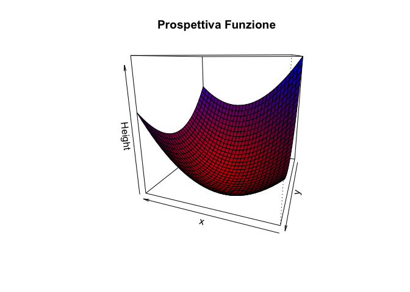

Notiamo come dal disegno la funzione ci offra una prospettiva di convessità rispetto alla retta delle Z pertanto ci aspettiamo che il valore trovato sia **minimo globale** e non **semplicimente locale**.

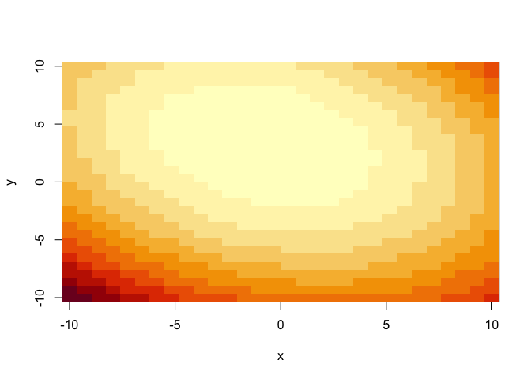

Anche da questo disegno possiamo notare come effettivamente per il punto $B=(-0.8,3.2)$ ci troviamo al centro della regione più chiara che indica appunto il minimo.

#### **3) Compito (c)**

Il metodo di **Newton** utilizza la seconda derivata pertanto è capace di trovare il punto di ottimo solamente con una iterazione se la funzione è una quadratica. Per cui nel nostro caso funziona perfettamente.

## **Problema 3**

Per risolvere la funzione:
$$\mathbf{f(x)=34exp^{-\frac12(\frac{x-88}{2})^2} + ( \frac{x}{10} -2sin(\frac{x}{10}))^2}$$
Decido perciò di crearmi una funzione in R che presa la funzione esegue per un intervallo il metodo di Simulated Annealing.

```r
func2 <- function(x) {
  34*(exp(1))^(-0.5*((x-88)/2)^2) + ((x/10) -2*sin(x/10))^2
}

epsilon <- function(y,y_old,temp) {
  exp(1)^(-(y - y_old)/temp)
}

setClass(Class="Risultati",
         representation(
            fine = "data.frame",
            soluzione_finale = "numeric",
            possibili_max = "data.frame",
            possibili_minimi = "data.frame"
          )
)

simulated_annealing <- function(fun, xmin, xmax){
  temp0 = 100000000
  xott = xmin
  yott = fun(xmin)

  xempsilon = xmin
  yepsilon = fun(xmin)

  fine <- data.frame("X" = numeric(), "Y" = numeric(),stringsAsFactors = FALSE)

  xprob <- data.frame("X" = numeric(), "Y" = numeric(),stringsAsFactors = FALSE)

  xprob[nrow(xprob) + 1,] = c(xott,yott)
  minimi <- data.frame("X" = numeric(), "Y" = numeric(),stringsAsFactors = FALSE)
  for(i in xmin:xmax){

    x_new = i
    y_new = fun(i)

    #calcolo minimi
    z <- grad(func2, x_new)

    if(z <= 0.01 & z >= -0.01){
      minimi[nrow(minimi) + 1,] = c(x_new,y_new)
    }

    if(yott >= y_new ){
      # mi salvo le soluzioni ottimali
      fine[nrow(fine) + 1,] = c(x_new,y_new)
    } else {
    random <- runif(1,0,10)
      if(random < epsilon(y_new,yepsilon,temp0)){
        xprob[nrow(xprob) + 1,] = c(x_new,y_new)
      }
    }
    xott = i
    yott = fun(i)
    temp0 = temp0 - 20
    xempsilon = i
    yepsilon = fun(i)
  }
  x <- fine[which.min(fine$Y),]
  x <-  as.list(x)
  print(paste0("Minimo Globale è in: (",x[1],",",x[2],")"))
  return(new( "Risultati",
              fine = fine,
              soluzione_finale= c(xott,yott),
              possibili_max = xprob,
              possibili_minimi = minimi))
}

result <- simulated_annealing(func2, -100,100)
```

```
## [1] "Minimo Globale è in: (0,0)"
```

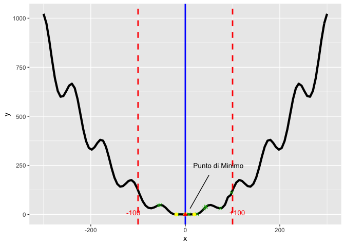

```r
result2 <- GenSA(fn = func2, lower=c(-100), upper=c(100))
final_par <- result2$par
final_result <- result2$value

print(paste0("Punto di minimo della funzione: ", round(final_par,2), ":", round(final_result,2)))
```

```
## [1] "Punto di minimo della funzione: 0:0"
```

Verrebbero in realtà valori non propriamente a 0 **ma arrotondando sono uguali alla soluzione da me calcolata**.

A work by [Alessandro Pontini](https://www.instagram.com/alessandro.pontini/)

*a.pontini1@campus.unimib.it*